# Chemical Properties Influencing Red Wine Quality

A Project for Exploratory Data Analysis with R

## Introduction

This report explores various chemical properties that could influence red wine’s quality.

The data set is sourced from:

P. Cortez, A. Cerdeira, F. Almeida, T. Matos and J. Reis.  
Modeling wine preferences by data mining from physicochemical properties.  
In Decision Support Systems, Elsevier, 47(4):547-553. ISSN: 0167-9236.

Available at:  
[@Elsevier] http://dx.doi.org/10.1016/j.dss.2009.05.016  
[Pre-press (pdf)] http://www3.dsi.uminho.pt/pcortez/winequality09.pdf  
[bib] http://www3.dsi.uminho.pt/pcortez/dss09.bib

### Overview of Data Set

```
## 'data.frame':    1599 obs. of  13 variables:
##  $ X                   : int  1 2 3 4 5 6 7 8 9 10 ...
##  $ fixed.acidity       : num  7.4 7.8 7.8 11.2 7.4 7.4 7.9 7.3 7.8 7.5 ...
##  $ volatile.acidity    : num  0.7 0.88 0.76 0.28 0.7 0.66 0.6 0.65 0.58 0.5 ...
##  $ citric.acid         : num  0 0 0.04 0.56 0 0 0.06 0 0.02 0.36 ...
##  $ residual.sugar      : num  1.9 2.6 2.3 1.9 1.9 1.8 1.6 1.2 2 6.1 ...
##  $ chlorides           : num  0.076 0.098 0.092 0.075 0.076 0.075 0.069 0.065 0.073 0.071 ...
##  $ free.sulfur.dioxide : num  11 25 15 17 11 13 15 15 9 17 ...
##  $ total.sulfur.dioxide: num  34 67 54 60 34 40 59 21 18 102 ...
##  $ density             : num  0.998 0.997 0.997 0.998 0.998 ...
##  $ pH                  : num  3.51 3.2 3.26 3.16 3.51 3.51 3.3 3.39 3.36 3.35 ...
##  $ sulphates           : num  0.56 0.68 0.65 0.58 0.56 0.56 0.46 0.47 0.57 0.8 ...
##  $ alcohol             : num  9.4 9.8 9.8 9.8 9.4 9.4 9.4 10 9.5 10.5 ...
##  $ quality             : int  5 5 5 6 5 5 5 7 7 5 ...
```

```
##        X          fixed.acidity   volatile.acidity  citric.acid
##  Min.   :   1.0   Min.   : 4.60   Min.   :0.1200   Min.   :0.000
##  1st Qu.: 400.5   1st Qu.: 7.10   1st Qu.:0.3900   1st Qu.:0.090
##  Median : 800.0   Median : 7.90   Median :0.5200   Median :0.260
##  Mean   : 800.0   Mean   : 8.32   Mean   :0.5278   Mean   :0.271
##  3rd Qu.:1199.5   3rd Qu.: 9.20   3rd Qu.:0.6400   3rd Qu.:0.420
##  Max.   :1599.0   Max.   :15.90   Max.   :1.5800   Max.   :1.000
##  residual.sugar     chlorides       free.sulfur.dioxide
##  Min.   : 0.900   Min.   :0.01200   Min.   : 1.00
##  1st Qu.: 1.900   1st Qu.:0.07000   1st Qu.: 7.00
##  Median : 2.200   Median :0.07900   Median :14.00
##  Mean   : 2.539   Mean   :0.08747   Mean   :15.87
##  3rd Qu.: 2.600   3rd Qu.:0.09000   3rd Qu.:21.00
##  Max.   :15.500   Max.   :0.61100   Max.   :72.00
##  total.sulfur.dioxide    density             pH          sulphates
##  Min.   :  6.00       Min.   :0.9901   Min.   :2.740   Min.   :0.3300
##  1st Qu.: 22.00       1st Qu.:0.9956   1st Qu.:3.210   1st Qu.:0.5500
##  Median : 38.00       Median :0.9968   Median :3.310   Median :0.6200
##  Mean   : 46.47       Mean   :0.9967   Mean   :3.311   Mean   :0.6581
##  3rd Qu.: 62.00       3rd Qu.:0.9978   3rd Qu.:3.400   3rd Qu.:0.7300
##  Max.   :289.00       Max.   :1.0037   Max.   :4.010   Max.   :2.0000
##     alcohol         quality
##  Min.   : 8.40   Min.   :3.000
##  1st Qu.: 9.50   1st Qu.:5.000
##  Median :10.20   Median :6.000
##  Mean   :10.42   Mean   :5.636
##  3rd Qu.:11.10   3rd Qu.:6.000
##  Max.   :14.90   Max.   :8.000
```

The dataset contains 1,599 entries of red wine, each with 12 variables comprising 11 measured chemical properties and 1 subjective grading of the wine’s quality.

## Univariate Plots

### Histogram of Quality

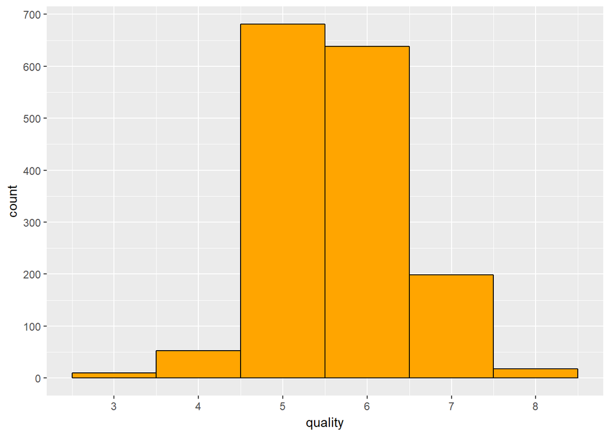

### Grouping of Quality Scores

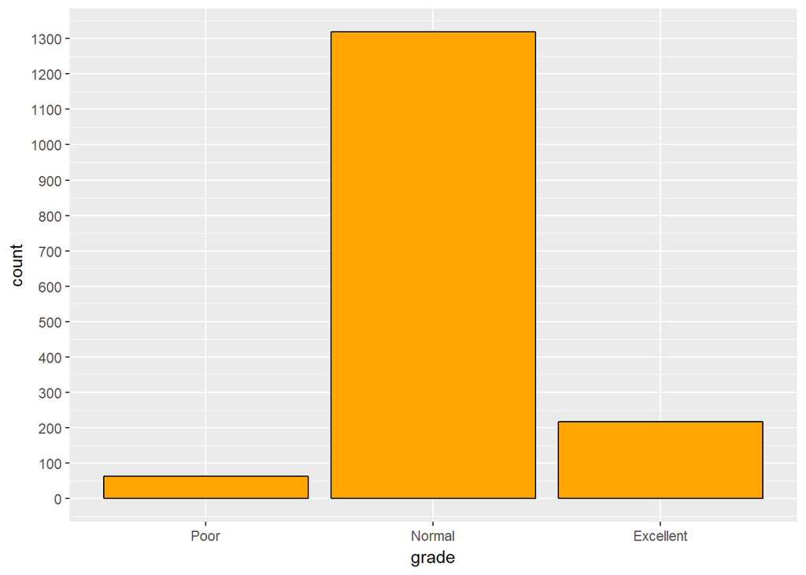

```
## # A tibble: 3 x 3
##   grade         n percentage
##   <fct>     <int> <chr>
## 1 Poor         63 3.94%
## 2 Normal     1319 82.5%
## 3 Excellent   217 13.6%
```

**Observation(s):**  
The red wine dataset is heavily represented by Normal grade quality score, with over 82% of wines being scored as such.

### Functions for Plots

As I began subsequent exploration, I was noticed that I was repeatedly plotting histograms and boxplots. I decided to write a function to plot histograms of various chemical properties to simplify the repetitive coding.

```r
#' Plot histogram using hardcoded colours for fill and line of bars.
#'
#' @param df Dataframe. For use as data source to ggplot().
#' @param x_var String. Variable a.k.a column name in data frame for x-axis in
#'    histogram.
#' @param binw Integer. Variable to effect binwidth of histogram. Defaults to
#'    NULL.
#' @param x_scale Vector of type "integer" or "double". Generated by function
#'    _seq_ to used to effect breaks on x-axis.
#'
#' @return None.
#'
#' @examples
#' plot_custom_histo(wine, "fixed.acidity")
#' plot_custom_histo(wine, "fixed.acidity", 1)
#' plot_custom_histo(wine, "fixed.acidity", 1, seq(4, 16, 2))
plot_custom_histo <- function(df, x_var, binw = NULL, x_scale = NULL) {
  p <- ggplot(data = df, aes_(as.name(x_var),
                              fill = I("steelblue2"),
                              color = I("white")
                              )
              ) +
       geom_histogram(binwidth = binw)

  if(is.vector(x_scale)) {
    p <- p + scale_x_continuous(breaks = x_scale)
  }

  p
}
```

And another function for boxplots of various chemical properties.

```r
#' Plot boxplot on "quality" using hardcoded colours for fill and line of bars.
#' Factors built-in variable "quality" to be used in x-axis.
#'
#' @param df Dataframe. For use as data source to ggplot().
#' @param y_var String. Variable a.k.a column name in data frame for y-axis.
#' @param y_scale Vector of type "integer" or "double". Generated by function
#'    _seq_ to used to effect breaks on y-axis.
#' @param on_grade Logical.
#'    If TRUE, boxplot is made using variable "grade" cut from "quality".
#'    If FALSE, boxplot is made using variable "quality"
#'
#' @return None.
#'
#' @examples
#' boxplot_on_quality(wine, "alcohol")
#' boxplot_on_quality(wine, "alcohol", seq(0, 16, 2))
#' boxplot_on_quality(wine, "alcohol", seq(0, 16, 2), on_grade = T)
boxplot_on_quality <- function(df, y_var, y_scale = NULL, on_grade = FALSE) {
  if(on_grade) {
    p <- ggplot(data = df, aes_(x = as.name("grade"),
                                y = as.name(y_var),
                                fill = I("steelblue2"),
                                color = I("blue")
                                )
                )
  }
  else {
    df$quality.factor <- factor(df$quality, ordered = T)
    p <- ggplot(data = df, aes_(x = as.name("quality.factor"),
                              y = as.name(y_var),
                              fill = I("steelblue2"),
                              color = I("blue")
                              )
                )
  }

  p <- p + geom_boxplot()

  if(is.vector(y_scale)) {
    p <- p + scale_y_continuous(breaks = y_scale)
  }

  p
}
```

### Fixed Acidity

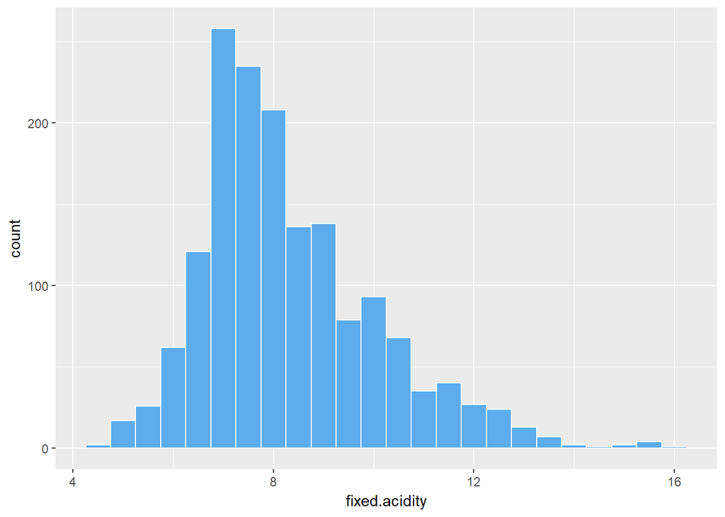

**Observation(s):**  
Normal distribution with positive skew and possible outliers after “14” on x-axis.

### Volatile Acidity

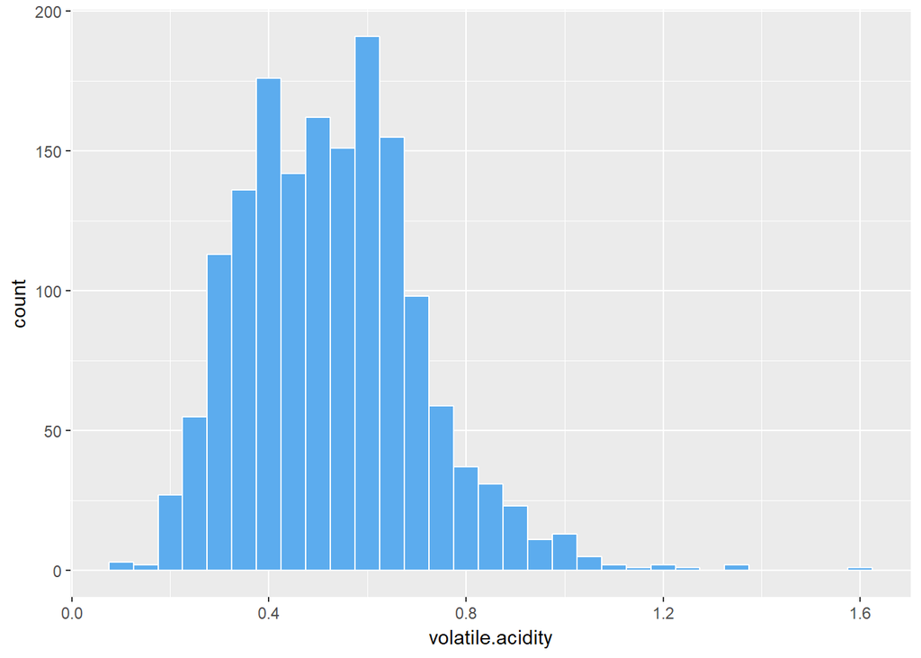

**Observation(s):**  
Normal distribution with positive skew and possible outliers after “1.1” on x-axis.

### Citric Acid

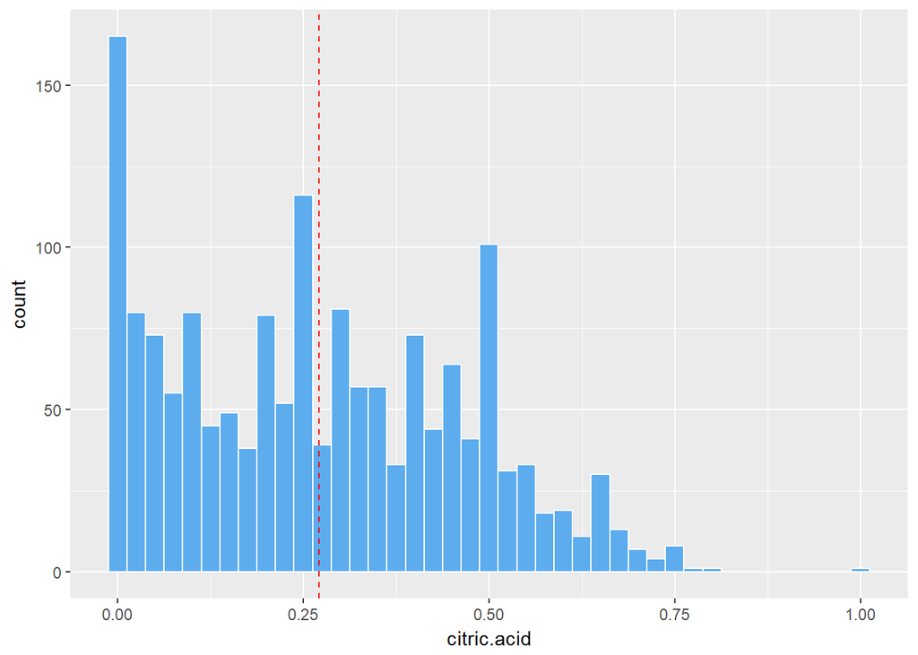

**Observation(s):**  
Multi-modal distribution of samples across the range of citric acid. The red dashed line represents the median value from the data set. It would be interesting to observe how this property exhibits itself across the different quality grades.

### Residual sugar

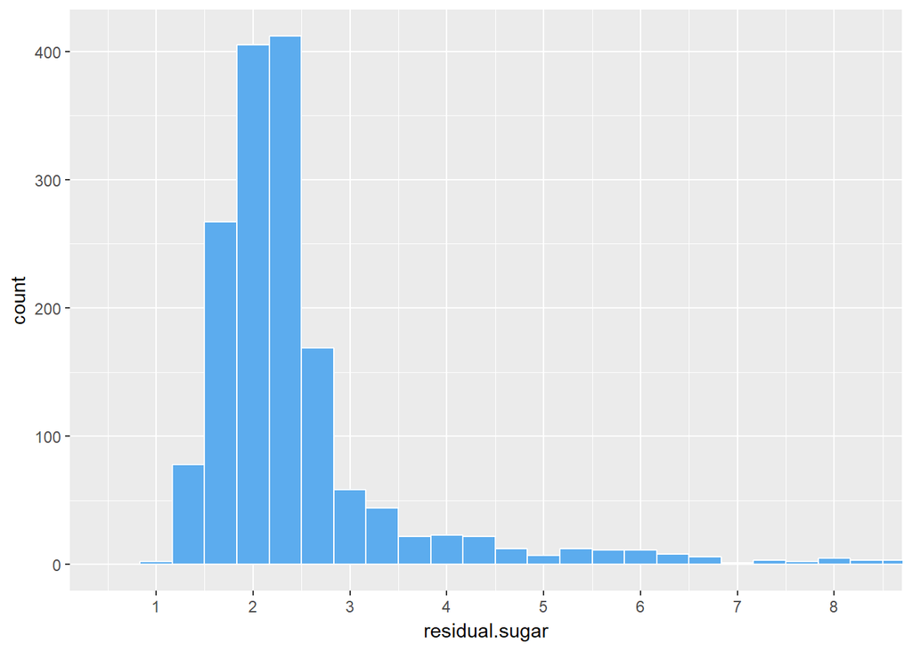

**Observation(s):**  
Normal distribution that is positively skewed, and is a candidate for application of log transformation.

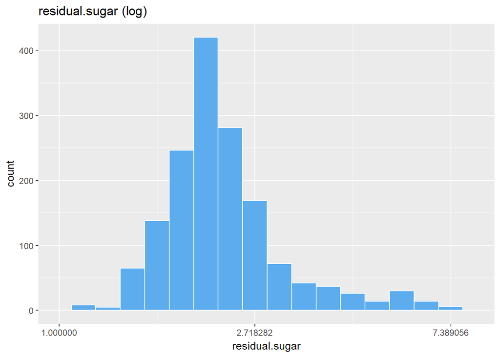

**Observation(s):**  
A more normal distribution after log transformation.

### Chlorides

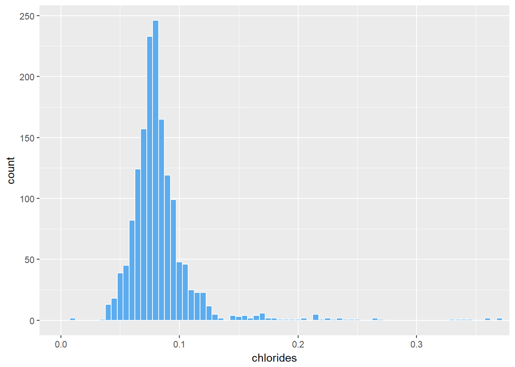

**Observation(s):**  
Normal distribution that is postively skewed. Outliers filtered out by limiting plot to points with 99% quantile, yet long-tail still exists.

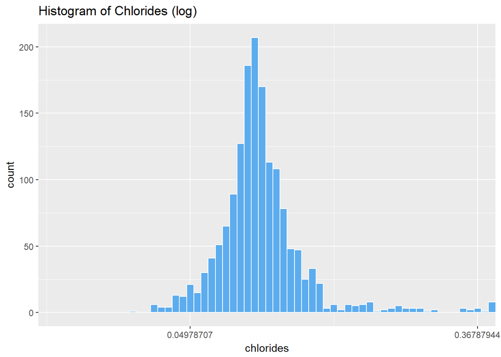

**Observation(s):**  
Normal distribution with long tail after log transformation.

### Free SO2

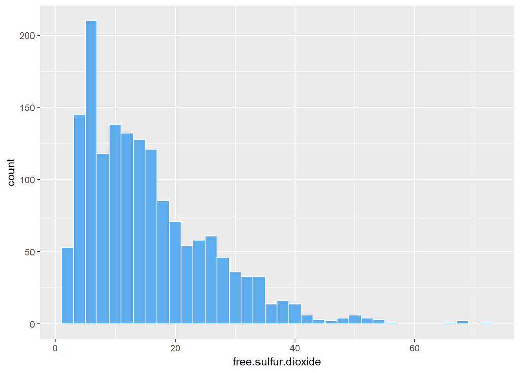

**Observation(s):**  
This positively skewed plot almost has a log normal distribution.

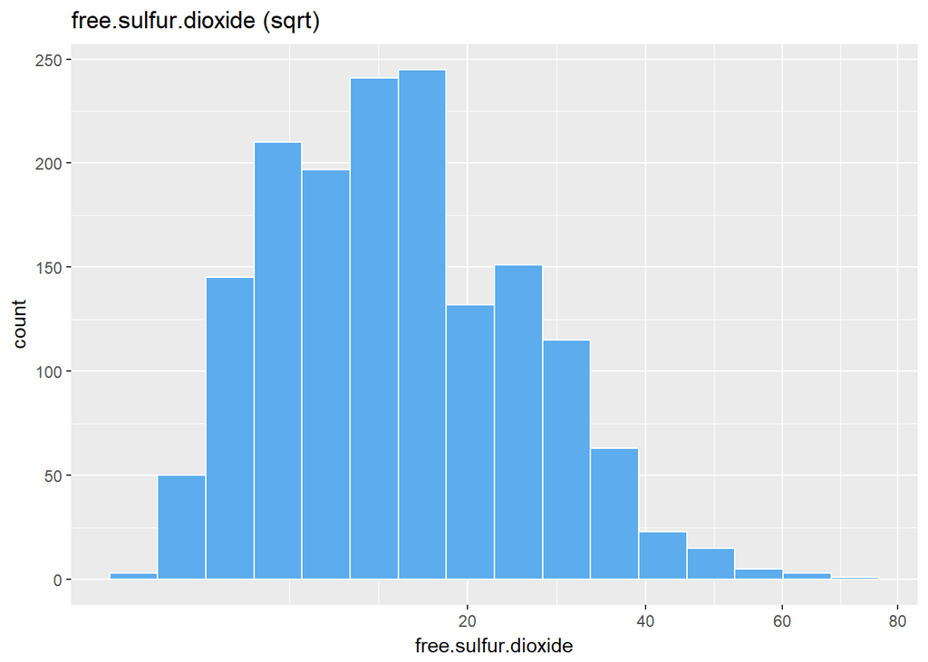

**Observation(s):**  
Transformed plot using square-root has a more normal distribution.

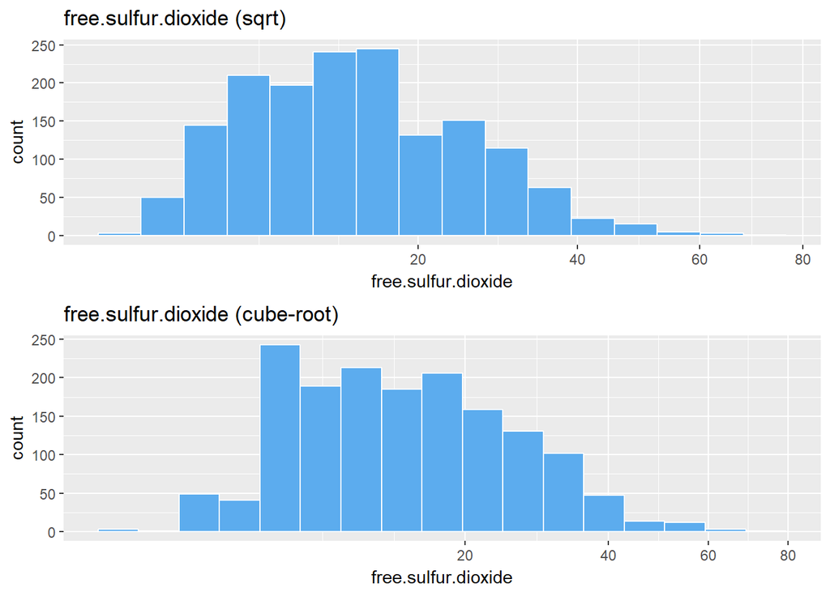

**Observation(s):**  
Applying cube-root transformation did not improve the distribution.

### Total SO2

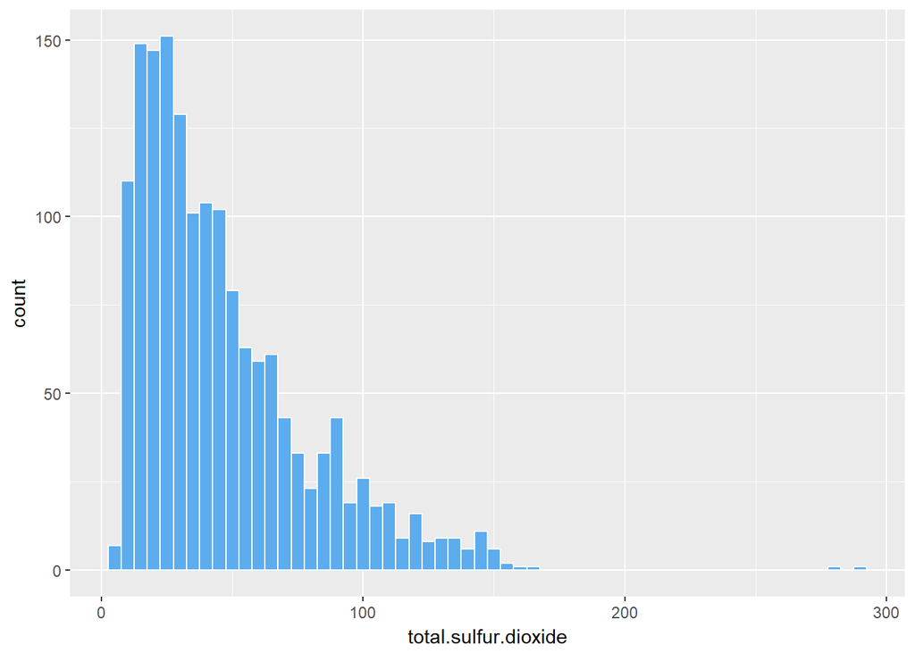

**Observation(s):**  
This positively skewed plot almost has a log normal distribution, and resembles the shape of plot for “free sulfur dioxide”.

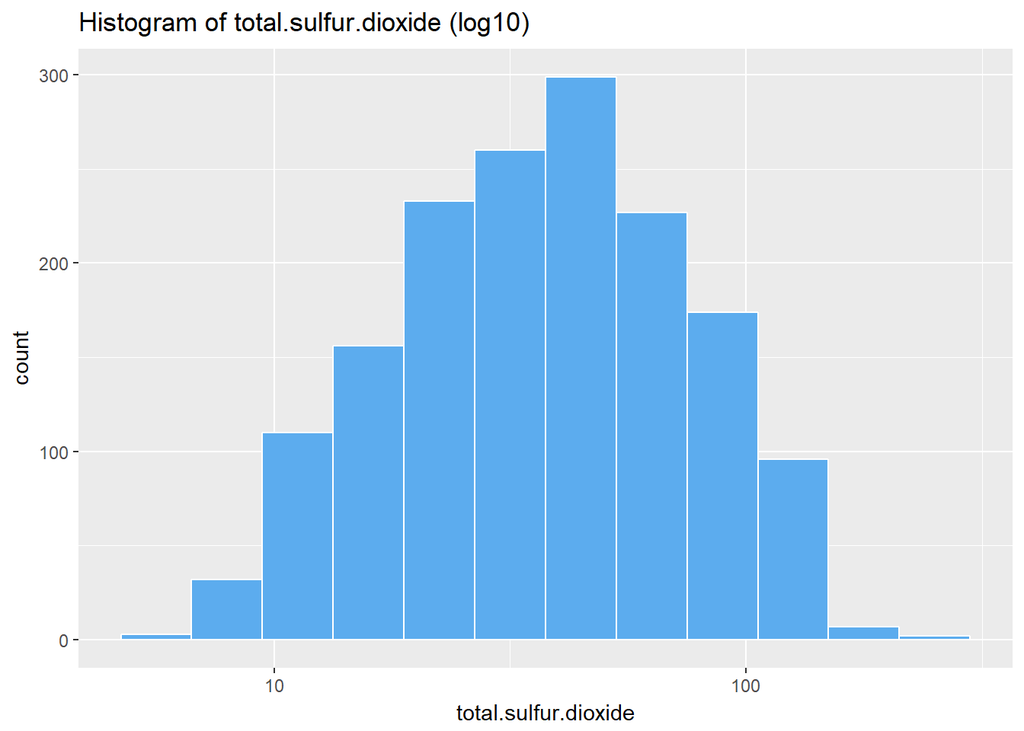

**Observation(s):**  
Transformed plot using log10 gives a normal distribution.

### Density

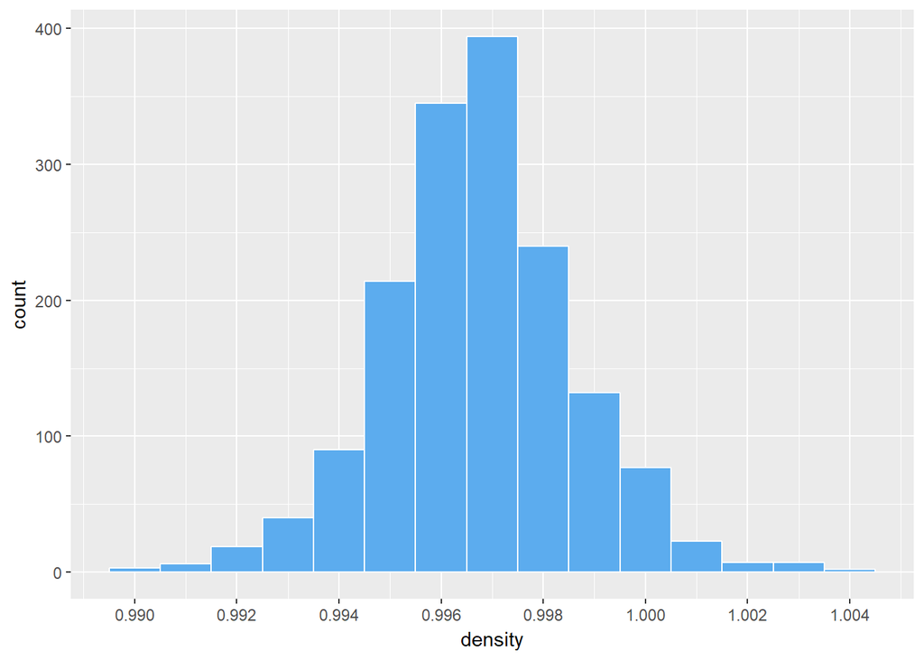

**Observation(s):**  
Normal distribution.

### pH

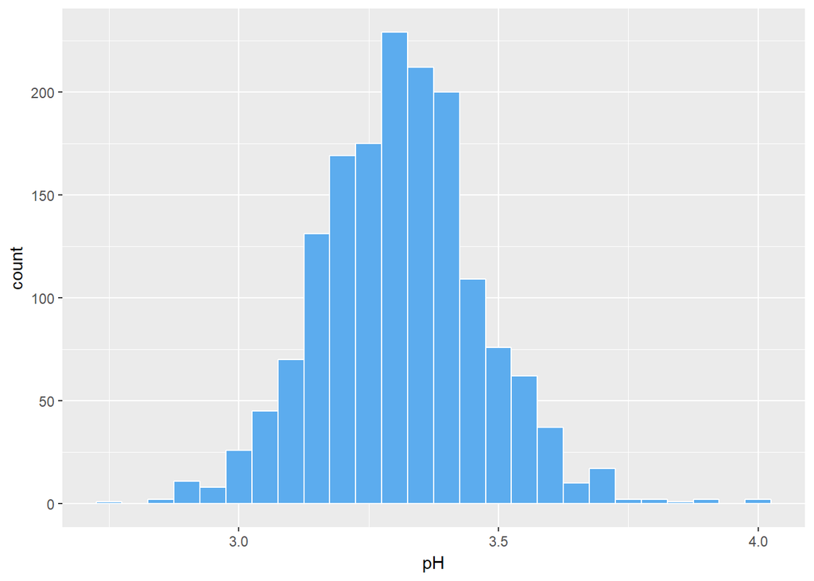

**Observation(s):**  
Normal distribution.

### Sulphates

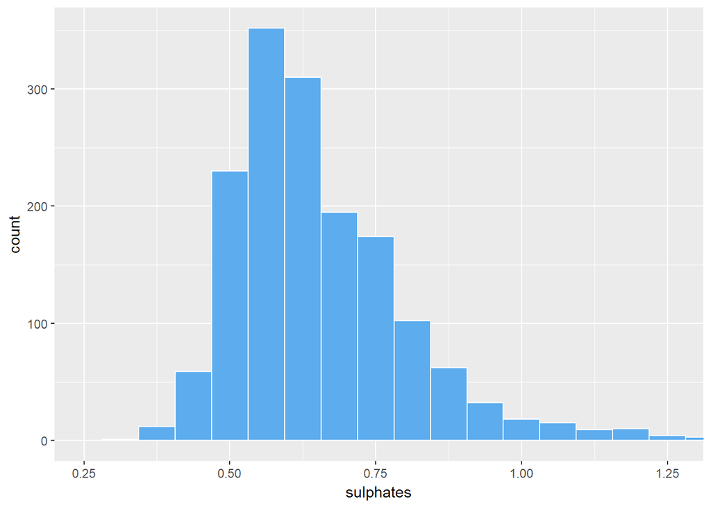

**Observation(s):**  
This positively skewed plot almost has a log normal distribution, and long-tail spread (even after filtering data points beyond the 99% quantile).

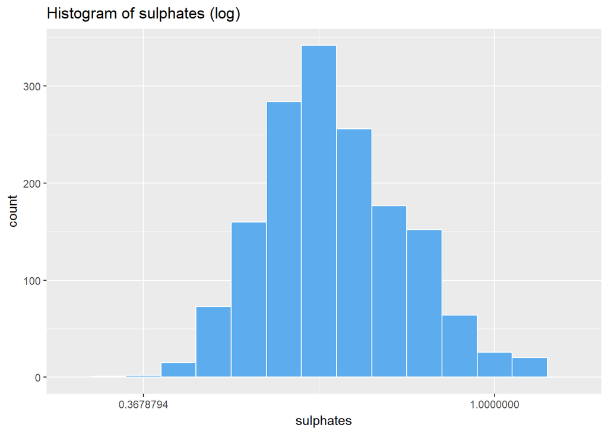

**Observation(s):**  
Normal distribution after transforming with log and removing points beyond 99% quantile.

### Alcohol

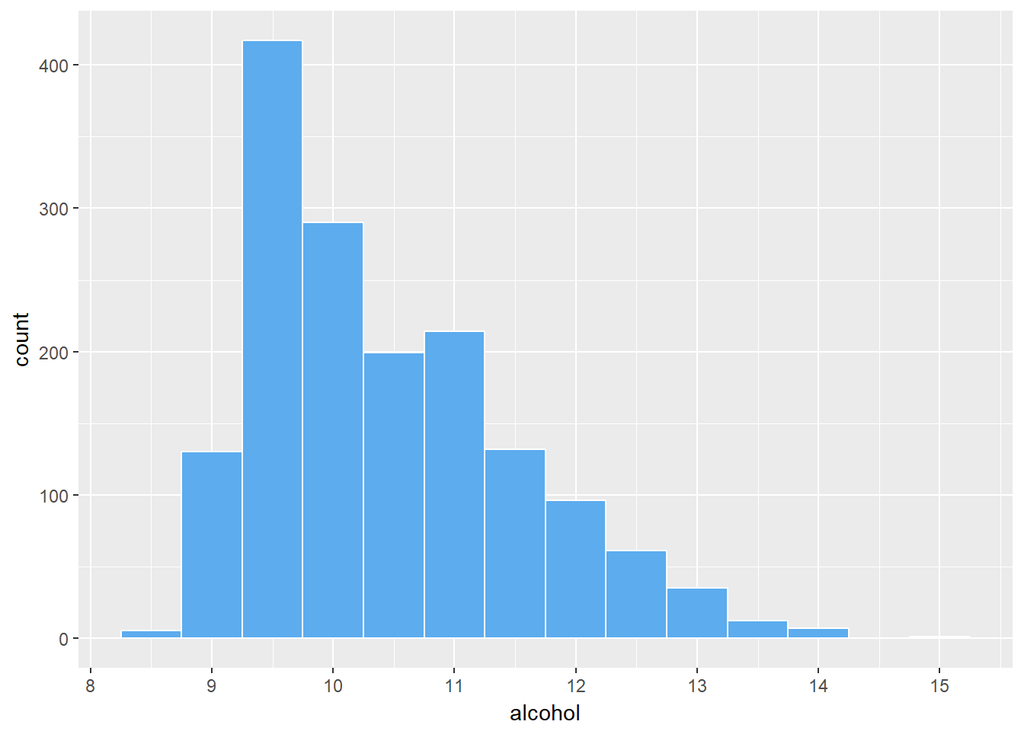

**Observation(s):**  
Positively skewed normal distribution plot.

## Univariate Analysis

### What is the structure of your dataset?

Dataset of red wine has 1,599 observations with 13 variables. 11 of those variables represent measured chemical properties in the wine, and 1 represents subjective quality score given by wine experts. The remaining variable represents a numbering sequence for entries in the dataset.

### What is/are the main feature(s) of interest in your dataset?

Quality score and citric acid concentrtion are the main features of interest.

The distribution of citric acid is multi-modal, and I’d like to see how this ties in with quality score. Citric acid concentration is said to give wine a fruity flavour.

### What other features in the dataset do you think will help support your investigation into your feature(s) of interest?

I think alcohol and sulphates could contribute to the variation of quality.

### Did you create any new variables from existing variables in the dataset?

I created a new variable called “grade” to represent the grouping of “quality” scores.

The quality score of wines in dataset range from 3 to 8. The distribution of quality scores suggest that wines can be broadly grouped into Poor, Normal, Excellent grades where:

1. Poor has quality score 3 - 4
2. Normal has quality score 5 - 6
3. Excellent has quality socre 7 - 8

The revised grading can help enhance visualization with respect to wine quality by reducing information overload.

### Of the features you investigated, were there any unusual distributions? Did you perform any operations on the data to tidy, adjust, or change the form of the data? If so, why did you do this?

Yes, several properties had histograms that were skewed (positively), which benefitted from transformation and cut-off (at 99% quantile) to produce a more normal distribution.

Between histograms of all chemical properties, the “citric.acid” histogram must be the most unusual with its multi-modal distribution.

Posts in [StackExchange](https://stats.stackexchange.com/questions/209241/what%20-transformation-should-i-use-for-a-bimodal-distribution) suggested that monotonic transformation may not be useful in this case.

## Bivariate Plots

Creating a scatter plot matrix with “grade” and omitting “quality”.

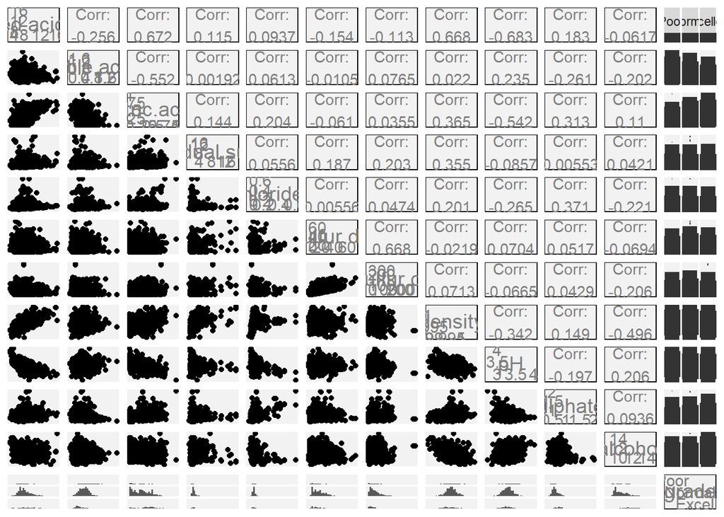

**Observation(s):**  
Citric Acid has interesting correlation with:  
1. Density (r = 0.36)  
2. Sulphates (r = 0.31)

No further exploration of citric acid against fixed acidity and volatile acidity is taken, partly because of the relatively higher correlation (> 0.5). Due to this correlation, it stands to reason that the change in citric acid concentration will be accompanied by a corresponding change in those 2 properties.

### Citric Acid by Grade

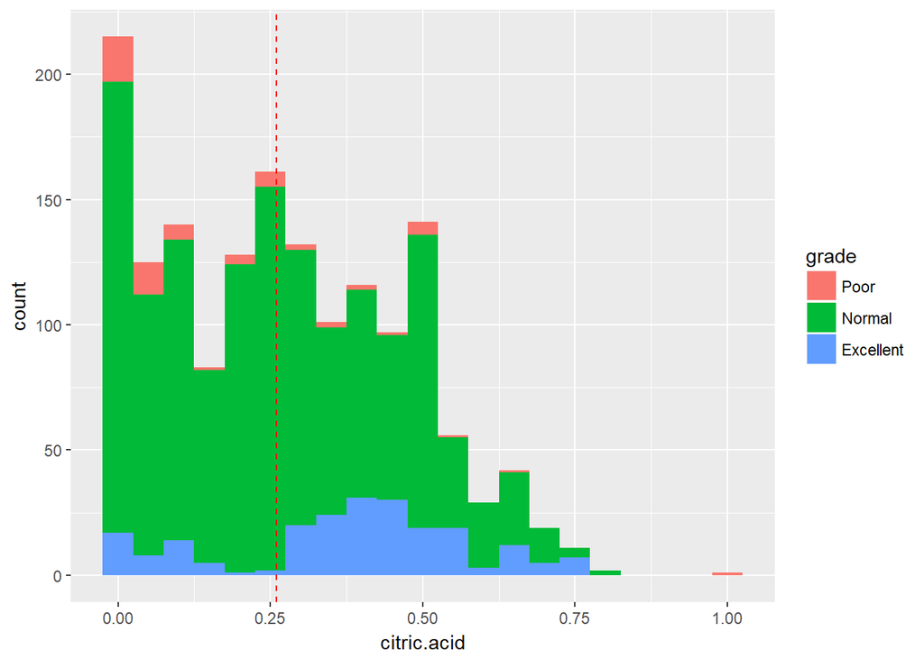

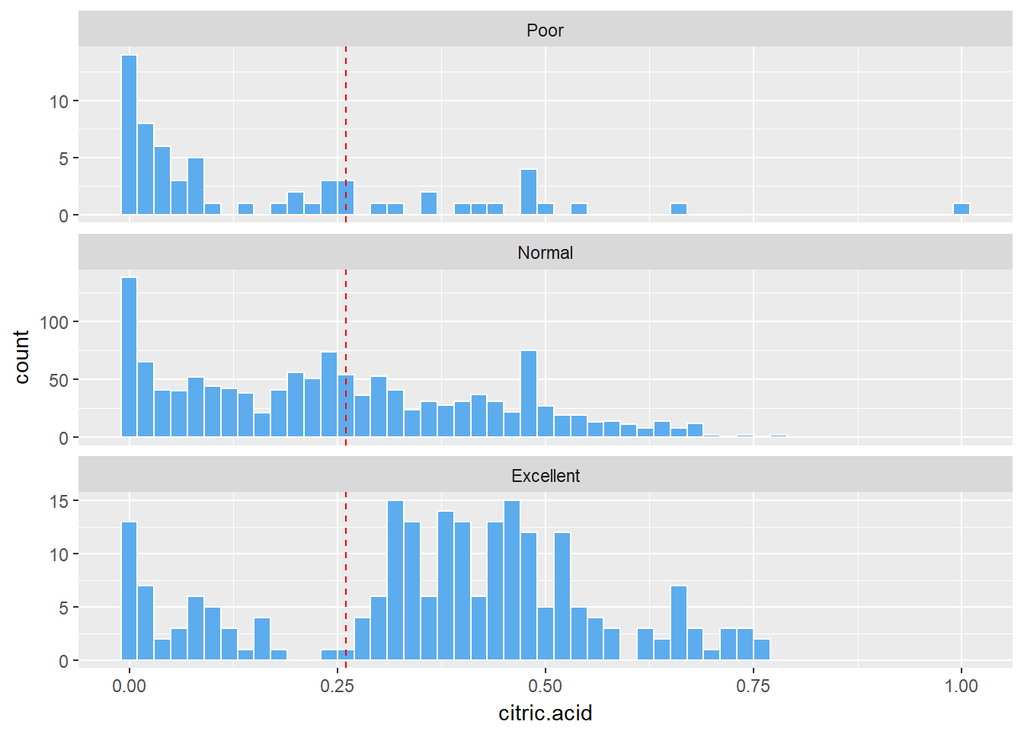

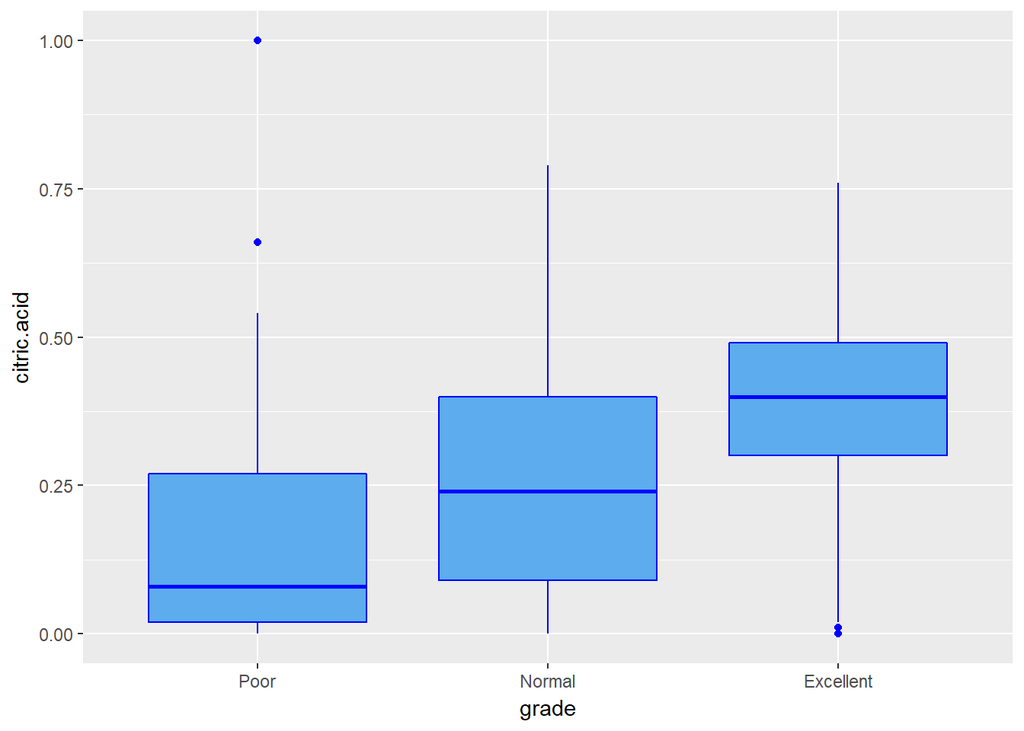

This resonates with me well since acidity of wine is said to be one of its most appealing characteristics according to [Total Wine’s article on acidity & crispness](http://www.totalwine.com/wine-guide/wine-acidity-crispness).

But why then do some Excellent wines have extremely low acidity? Are there other chemical properties making up for this? Higher alcohol? Lower residual sugar? What about sulphates?

According to [Total Wine’s article on balance](http://www.totalwine.com/wine-guide/wine-balance), “Wine high in acid should be balanced with the proper amount of residual sugar.” So, the reverse is true - that wine low in acid should have a counter of residual sugar to create a balance that raises the quality of wine.

### Residual sugar by Grade

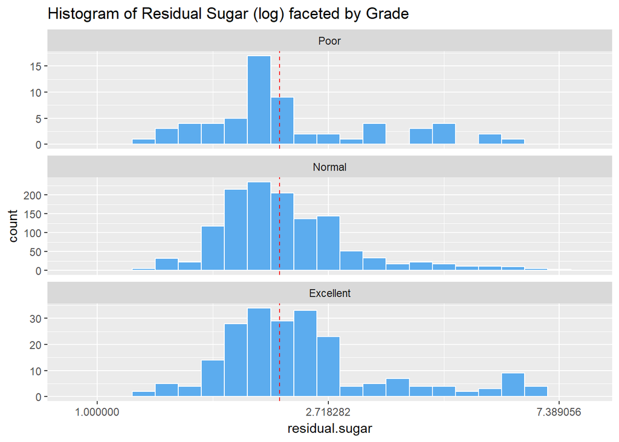

**Observation(s):**  
Range bound residual sugar concentration in Normal and Excellent wine at 1.9 - 2.7.

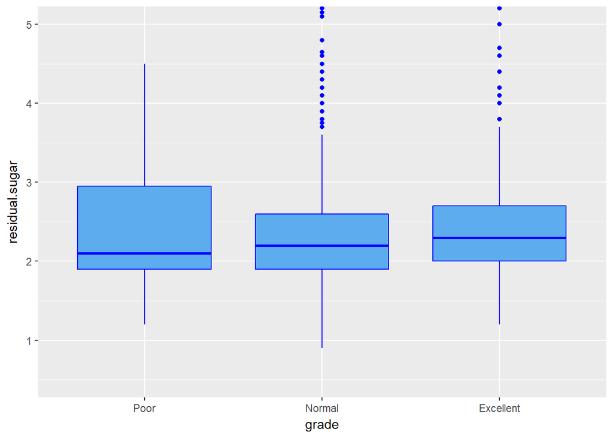

**Observation(s):**  
Range bound residual sugar concentration in Normal and Excellent wine at 1.9 - 2.7, whereas Poor quality wines have wider spread of residual sugar.

So, does residual sugar make up for low citric acid in Excellent wine?

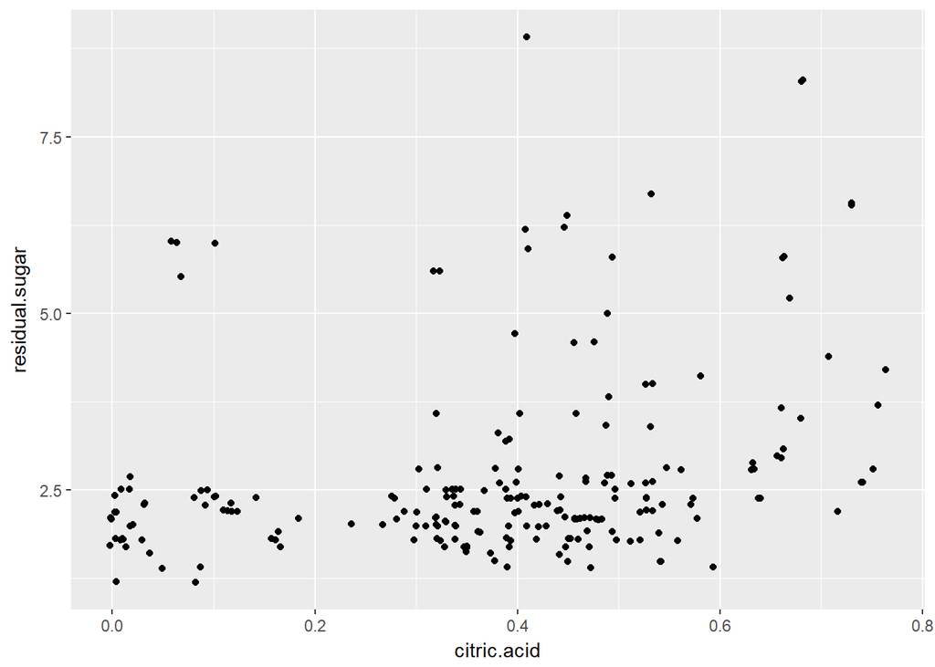

**Observation(s):**  
Excellent wines do not seem to have observable variation in residual sugar concentration for citric acid between 0 - 0.6 g/dm<sup>3</sup>. Residual sugar appears range bound at 1.25 - 2.5 g/dm<sup>3</sup>.

I can see that for citric acid concentration beyond 0.6 g/dm<sup>3</sup>, Excellent wines tend to have higher residual sugar, with levels starting out at 2.4 g/dm<sup>3</sup>.

The table below supports this.

This is rather baffling. One explanation is that citric acid concentration of 0 - 0.6 g/dm<sup>3</sup> is considered “low”, and hence, is balanced with low residual sugar levels. High citric acid concentration starts beyond 0.6 g/dm<sup>3</sup>.

This is counter-intuitive since the scatter plot shows 2 clusters of wine around:

1. citric acid levels of 0 - 0.18 g/dm<sup>3</sup> (which can be construed as “low” or non-fruity)
2. citric acid levels of 0.25 - 0.6 g/dm<sup>3</sup> (which can be construed as “high” or fruity)

```
## # A tibble: 3 x 4
##   citric_cut median_residual_sugar mean_residual_sugar     n
##   <fct>                      <dbl>               <dbl> <int>
## 1 [0,0.2]                     2.20                2.38    45
## 2 (0.2,0.6]                   2.20                2.58   148
## 3 (0.6,0.8]                   3.30                4.10    24
```

### Density vs Citric Acid

What about the ratio of Density to Citric Acid? Does that influence the quality of wine?

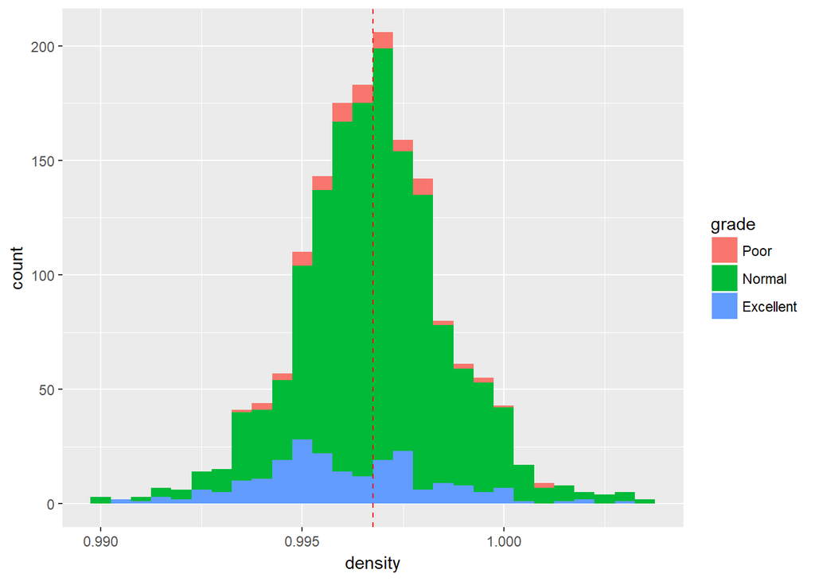

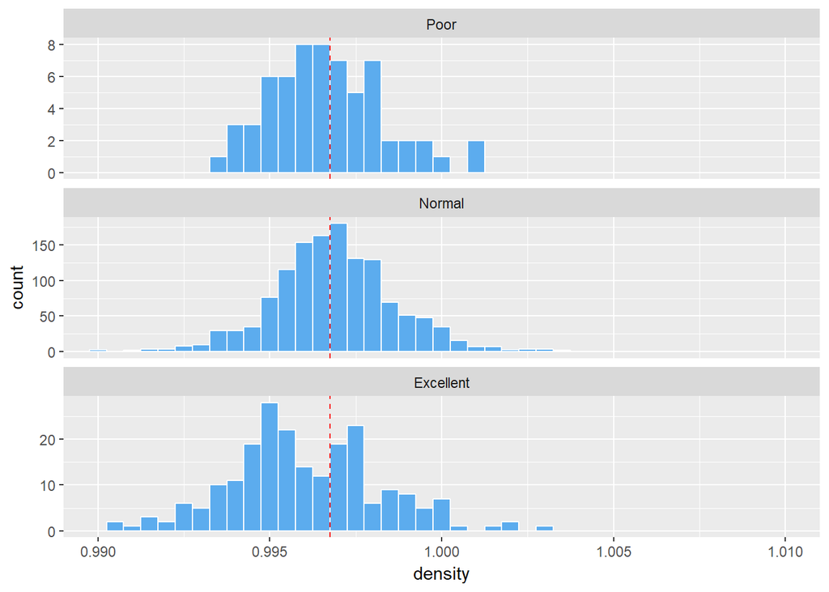

**Observation(s):**  
Multi-modal (bi-modal) distribution of Density in Excellent grade wines - similar to the distribution observed for Citric Acid in wines.

### Sulphates by Grade

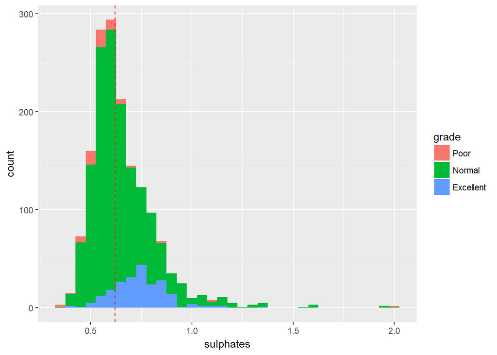

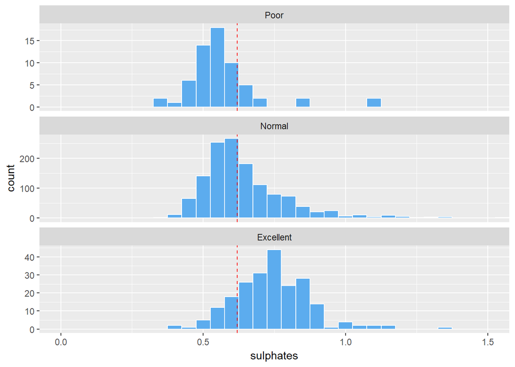

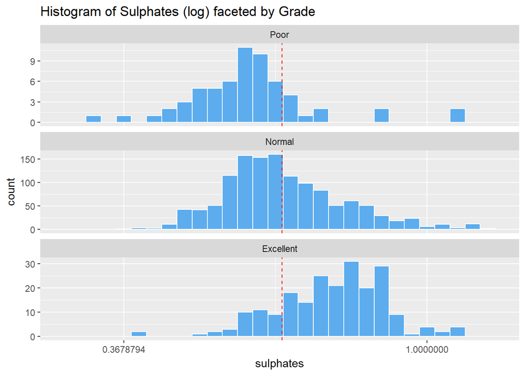

**Observation(s):**  
Excellent wines have sulphates higher than the median in the dataset, suggesting that sulphates play an important role in wine quality. This is supported by boxplot below.

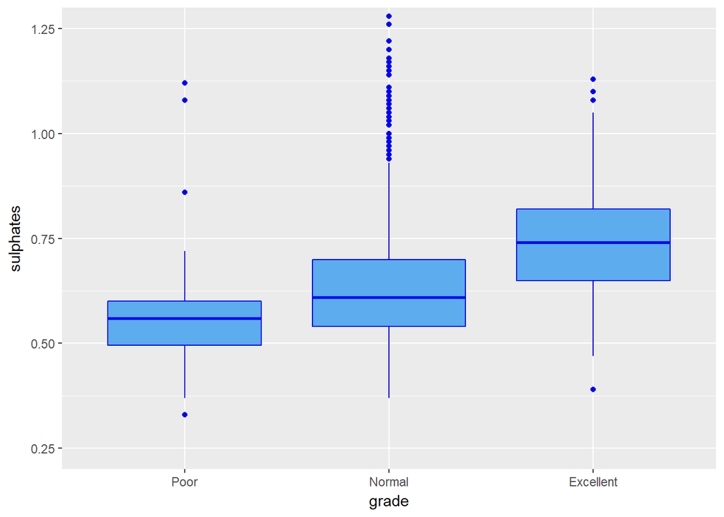

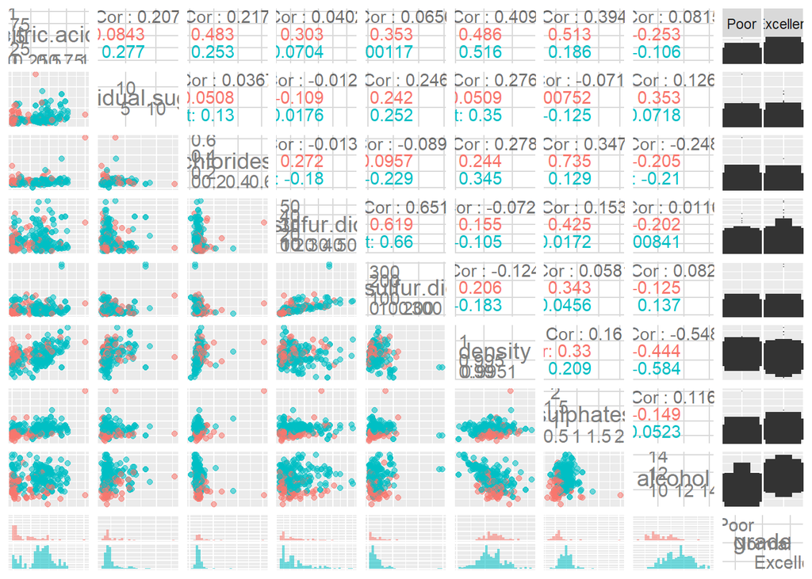

**Observation(s):**  
When Normal grade wines have been removed, the correlation for citric acid with density increased to 0.409, while sulphates increased to 0.39.

## Bivariate Analysis

### Talk about some of the relationships you observed in this part of the investigation. How did the feature(s) of interest vary with other features in the dataset?

I explored “grade” by “citric.acid” following the multi-modal distribution discovered in univariate plot for citric acid.

Interestingly, citric acid supposedly gives wine a fruity character. Excellent wines tend to have citric acid between 0.25 - 0.60 g/dm<sup>3</sup>, while the lower grade wines tend to have lower citric acid concentration.

However, there is a collection of wines with low citric acid concentration (0 - 0.20 g/dm<sup>3</sup>) that has been graded as Excellent. Perhaps to achieve that quality, the winemakers have infused a balance to the wines by altering the residual sugar concentration of the wine.

However, average sugar concentration of Excellent wines did not change between the range of citric acid levels of 0 - 0.6 g/dm<sup>3</sup>. Higher sugar concentration was observed for citric levels beyond 0.6 g/dm<sup>3</sup>.

On the other hand, density appeared to demonstrate tighter correlation with citric acid concentration due to the multi-modal distribution exhibited with Excellent wines.

### Did you observe any interesting relationships between the other features (not the main feature(s) of interest)?

Density is negatively correlated with alcohol (r = -0.55) and is positively correlated with residual sugar (r = 0.28). The fact that density is correlated with these two properties is mentioned in the research paper - density of wine is close to that of water depending on the percent of alcohol and sugar content.

### What was the strongest relationship you found?

The strongest relationship for citric acid is with density.

# Density over Citric Acid by Grade

In the following exploration of density over citric acid, I have made plots using a subset of Poor and Excellent grades wines. The exclusion of Normal grade wines in the plots provides a cleaner visual for comparing the influence of studied chemical properties have over wine’s quality / grade.

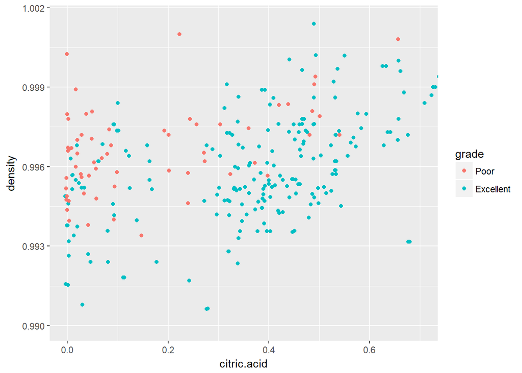

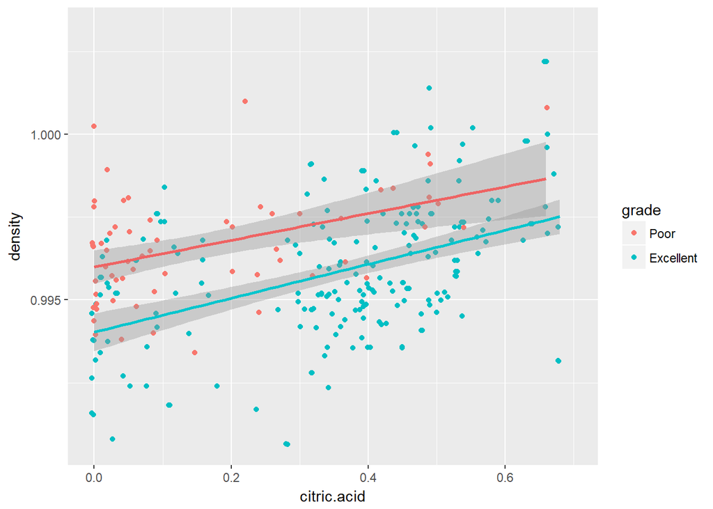

**Observation(s):**

1. Poor grade wines tend to have higher density across citric acid concentration while the Excellent grade wines tend to have lower density across the range.
2. There are 2 distinct ranges of citric acid concentration in Excellent wines; (low) 0 - 0.15 and (high) 0.3 - 0.55 g/dm<sup>3</sup>. Wines that fall between the 2 ranges tend to be of Poor grade.

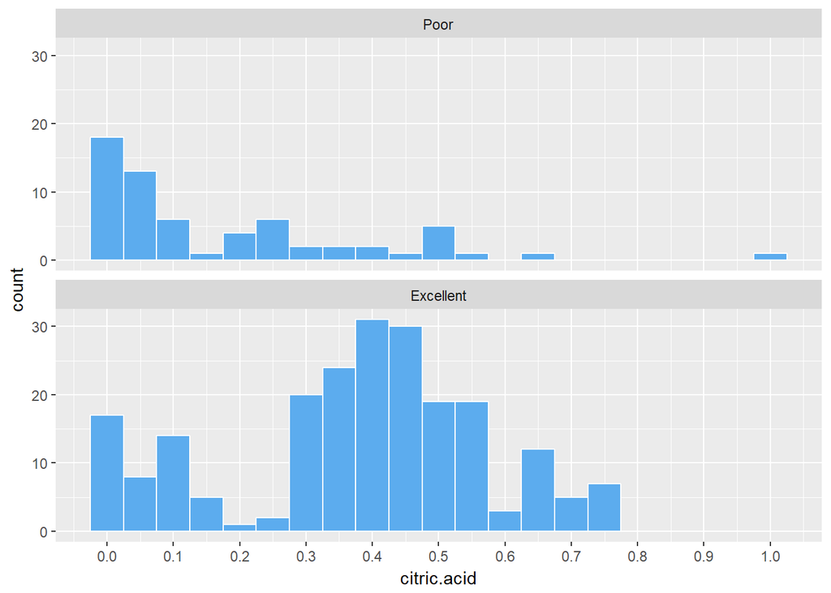

# Sulphates over Citric Acid by Grade

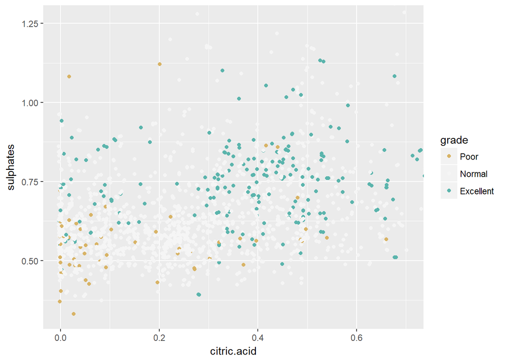

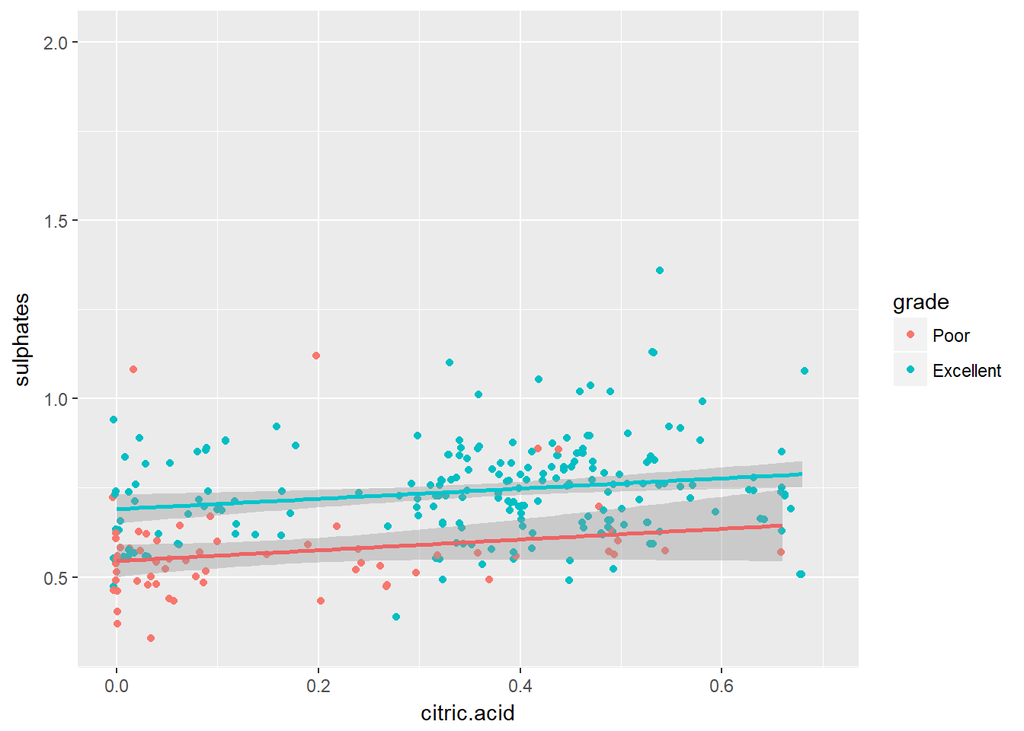

**Observation(s):**  
The relationship between citric acid and sulphates concentration in predicting grade is inverse that of density, i.e. Excellent wines tend to have higher sulphates compared to Poor wines.

## Multivariate Analysis

### Talk about some of the relationships you observed in this part of the investigation. Were there features that strengthened each other in terms of looking at your feature(s) of interest?

1. I explored citric acid in relation to grade. I filtered away the over-represented Normal grade wine since these could be a result of  
   “safe” evaluations by wine graders.
2. Excellent wines have lower density but higher sulphates concentration compared to Poor quality wines.
3. Both density and sulphates display positive correlation with citric acid, albeit with moderate (density-citric) and low strength (sulphates-citric).

### Were there any interesting or surprising interactions between features?

The 2 ranges of citric acid concentration where wines were graded Excellent was interesting. This suggests that there are 2 distinct preferences for wine when it comes to “fruitiness”.

## Final Plots and Summary

### Plot One

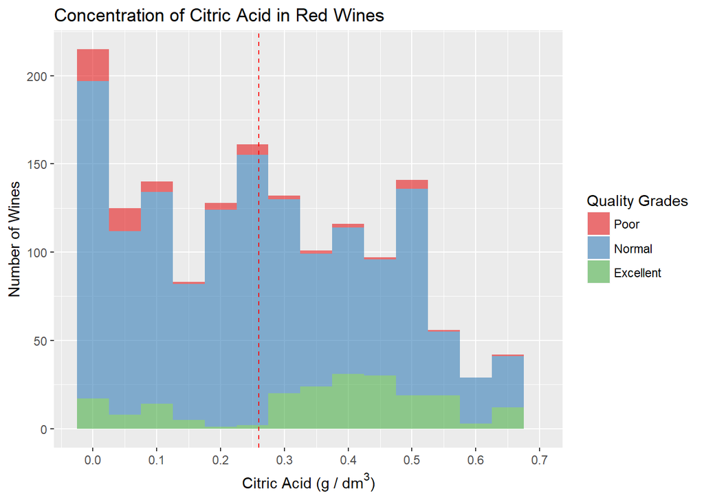

### Description One

The histogram plot of citric acid concentration in red wines illustrates differed from histogram plots of other chemical properties in that it has a multi-modal distribution.

This plot prompted me to explore the relation of citric acid against wine quality (grade) further.

The multi-modal distribution is more apparent when the plot is coloured by the grade of red wines; noticebly, Excellent grade wines have bi-modal distribution around 2 distinct citric acid concentration.

I was curious to discover what would make red wines with low citric acid concentration just as desirable as those with higher citric acid concentration?

### Plot Two

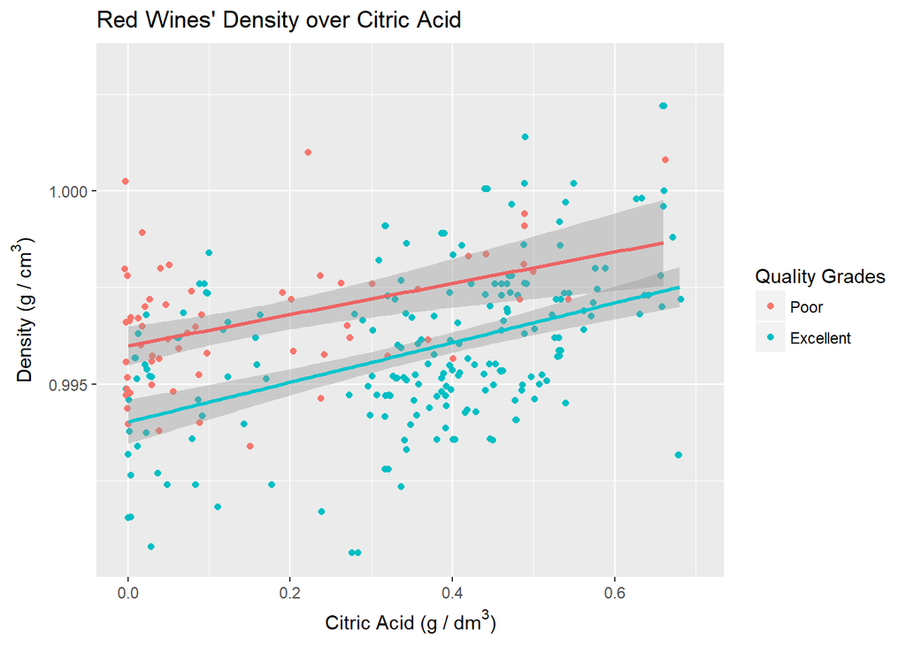

### Description Two

This plot of Density to Citric Acid shows that Excellent grade wines tend to cluster around 2 concentrations of Citric Acid:  
1. Low concentration of 0 - 0.15 g / dm<sup>3</sup>  
2. High concentration of 0.30 - 0.55 g / dm<sup>3</sup>

However, throughout the range of Citric Acid concentration, Density of Excellent wines tends to be lower than that of Poor wines.

### Plot Three

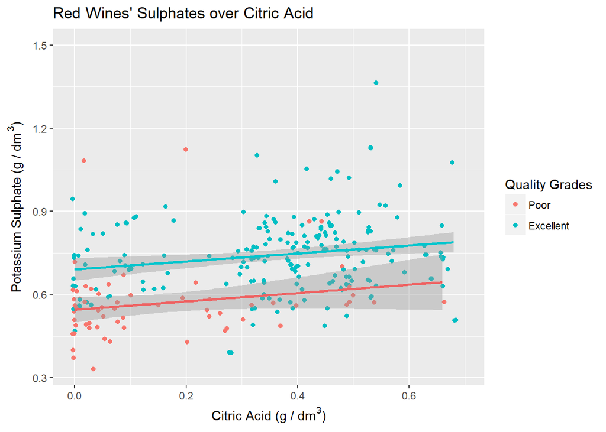

### Description Three

The relationship between Sulphates and Citric Acid concentration for the 2 grades of wine is the inverse of that between Density and Citric Acid. Here, Excellent wines tend to have higher Sulphates concentration across the range of Citric Acid compared to Poor wines.

## Reflection

I set out to look for chemical properties that may contribute to red wine’s quality, using a data set comprising of 1,599 wine entries with 11 chemical properties.

The quality rating of wines ranged from 3 - 8. Wines with quality ratings of 5 & 6 dominated the set of wine being studied. I decided that it would be easier to observe relationships if the range of quality score were grouped into 3 broader grades of Poor, Normal and Excellent.

Having looked at univariate plots of each property, I explored citric acid concentration due to its interesting multi-modal distribution.

By plotting citric acid coloured by the grade of wine, I observed that Excellent wine has bi-modal distribution centered over low (0 - 0.15 g/dm<sup>3</sup>) or high (0.30 - 0.55 g / dm<sup>3</sup>) citric acid concentration. I wanted to find out if there were other chemical properties that would make up for the different citric acid concentrations in order to yield high scoring wines. I was expecting to see that Excellent wines with low citric acid concentration might have notably different concentration of other chemical properties compared to their high citric acid counterparts.

I studied the relationship of density and sulphates with citric acid since a scatter plot matrix indicated correlations exist between these properties.

Density and sulphates in wines did not demonstrate trends that would compensate for low- or high citric acid concentrations in attaining Poor or Excellent grades. What was observed was that across the range of citric acid:

1. Excellent wines have lower density compared to Poor wines;
2. Excellent wines have higher sulphates compared to Poor wines; and,
3. Both density and sulphates have positive correlation with citric acid in Poor as well as Excellent wines.

Citric acid is known to give wine its fruity taste. I did not observe any trends in 2 other chemical properties (i.e. density and sulphates) that compensated for the low concentration of citric acid in making a wine Excellent as its high citric acid counterpart.

It appears that consumers’ personal preference for red wines with either low or high citric acid concentration (non-fruity or fruity) wines allows red wines with low citric acid to score as Excellent.

Aiding with the quality of wine are the density and sulphates concentration - Excellent wines have lower density but higher sulphates compared to Poor wines.

### Challenges & Future Work Possibilities

Trying to spot patterns in the data set was a challenge since the majority (over 82%) of wines was scored in the “Normal” grade, leaving less than 20% of wines to study for patterns contributing to Excellent and comparing that to Poor wines.

For instance, it was difficult to discern if citric acid levels in red wine which influence the wine’s fruitiness were range bound between 0 - 0.2 g/dm<sup>3</sup> and 0.25 - 0.60 g/dm<sup>3</sup>, or might also include a 3rd range of 0.60 - 0.80 g/dm<sup>3</sup>.

For future work, I expect that performing the analysis on a data set with larger representations of Poor and Excellent wines will yield more compelling observations.